# Leveling the Playing Field

How the MLB Competitive Balance Tax affects Team Performance

# Research Question

How have Major League Baseball (MLB) teams’ records and post-season performance changed before and after the competitive balance tax (CBT) was implemented in 1994?

[figure not shown]

[image source](https://en.wikipedia.org/wiki/Major_League_Baseball_logo)

# Data

## Sources

*Team Payrolls: 1950-2022*

We collected team payroll data from `baseball-reference.com`, an online baseball encyclopedia. Not all seasons have complete data, especially those closer to 1950. We started using data from 1969 rather than 1950 for better data. These payrolls amounts were also adjusted for inflation to try and get a better understanding of the differences in payrolls from year to year (by comparing real rather than nominal payrolls).

*Team Performance Data*

Sean Lahman began an effort to make MLB statistics publicly available starting in 1994. Since then, he and his team have updated a database containing different data frames in different formats for public use. (The most useful format for this project is comma-delimited values, csv’s.) The data frame we used is the `Teams.csv` data frame for regular season data. Thankfully, the data from the Lahman Baseball Database (see [documentation](https://www.seanlahman.com/files/database/readme2021.txt) has already been compiled into an R package: the `Lahman` package.

## Data Processing

The data from the Lahman database has been compiled into the `Lahman` package. The other data is loaded from the `data_raw` folder. The data frames from the `Lahman` package used are `Teams`.

The below code is the initial data wrangling of the data frames as well as a data dictionary for each data frame.

# Expectations

One variable’s distribution we estimated was team payroll–hypothesizing it to be bimodal (with teams either having very high or very low payrolls). This is disproved by the graph below, which shows a histogram of every team’s payroll. The visual is skewed to the right, indicating that our preliminary analysis was slightly flawed.

[interactive chart not shown]

Here are the expected relationships we discussed in our proposal:

> *One relationship we might expect to find is a positive correlation between each team’s yearly payroll and their season record measured in wins and losses. It is the assumption that team’s that have more funding (a larger payroll) should be performing better.*

Unfortunately, we could not find data that could provide an accurate representation of our second relationship assumption, stated below:

> *Another relationship we might expect to find is that the implementation of the competitive balance tax (CBT) has little to no effect on the team’s performance. It is predicted that the CBT is so inconsequential that it is almost negligible in terms of affecting team performance.*

# Data Visualizations

## Chart 1: Density Plot

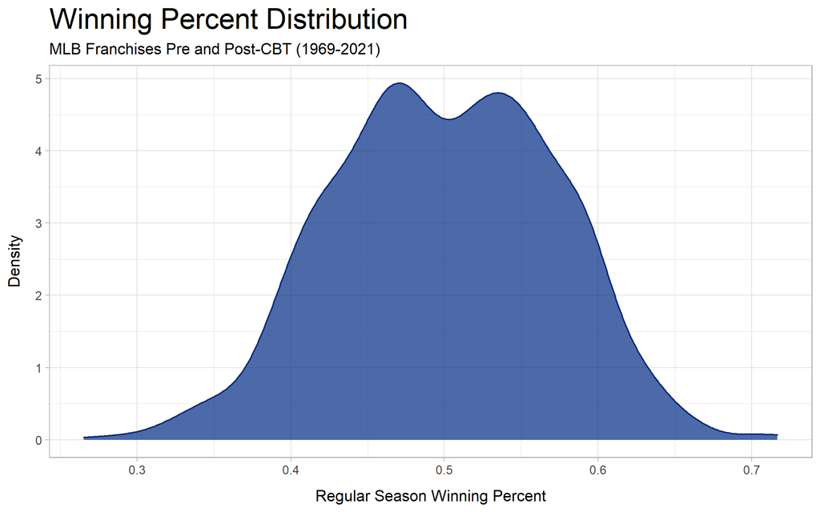

## Chart 2: Scatterplot

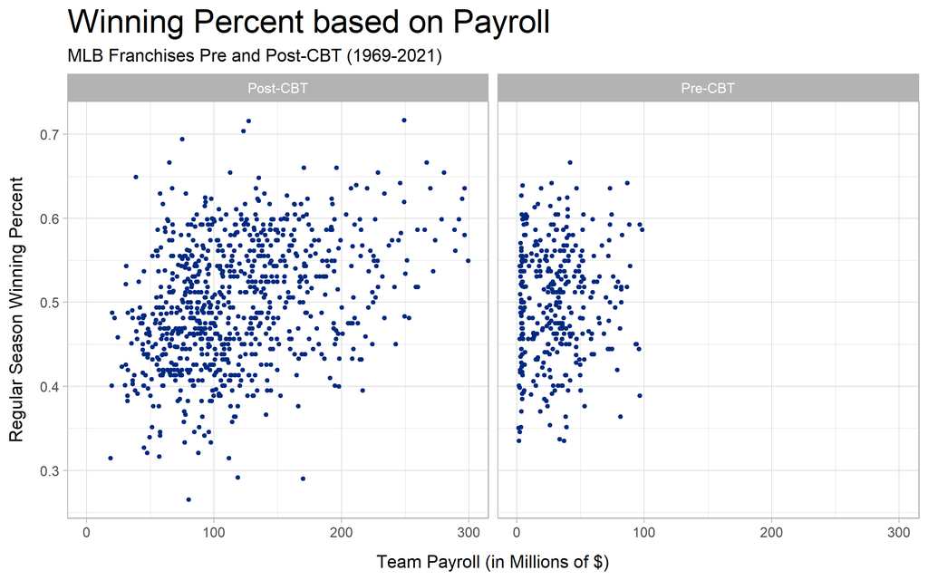

This visualization is a faceted scatterplot comparing team payroll and regular season winning percentage from the pre- and post-CBT eras. The pre-CBT data have a correlation of r = 0.074 and the post-CBT data have a correlation of r = 0.357. Given these values, there does not appear to be a linear relationship in the pre-CBT era. However, there is a moderately weak linear relationship for the post-CBT era.

## Chart 3: Dumbbell Chart

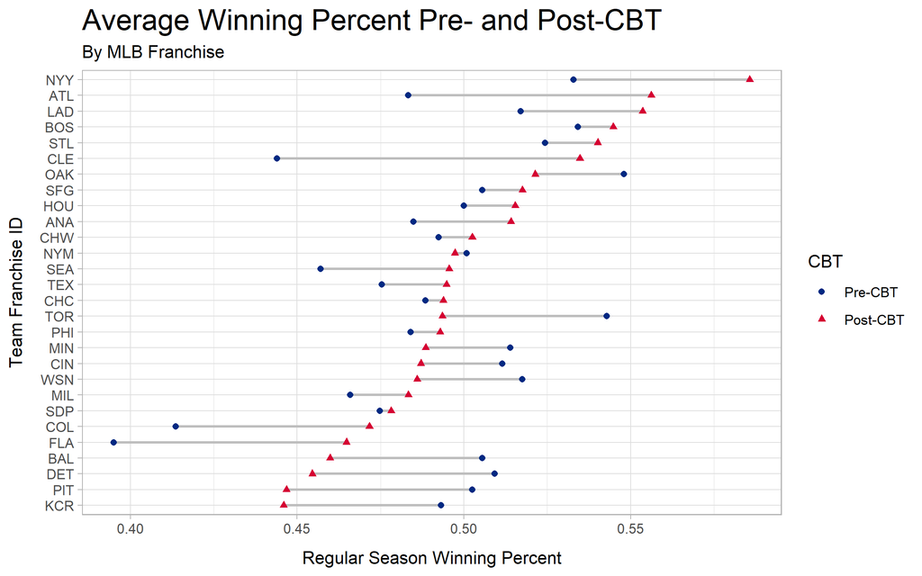

This plot displays the winning percentages of teams, specifically pointing out the differences between post and pre-CBT implementation. The data is organized from greatest to least post-CBT win percentage. Some teams’ average winning percentage increased in the post-CBT era, whereas some teams’ performance decreased. There are two teams not included in this visualization: the Arizona Diamondbacks and the Tampa Bay Rays. These franchises were not founded until 1998, so there is no pre-CBT era data to compare. The two teams with very low pre-CBT winning percentages–Colorado and Miami (formerly Florida)–have these because these franchises’ first season in MLB was 1993. Historically, expansion teams rarely achieve success in their opening season and it takes time to curate a competitive roster.

# Conclusion

# Appendix

## Data Dictionaries

There are three raw data sets used in this report `payroll_data`, `inflation_factors`, and `Teams`. The respective data dictionaries are below, in the same order as previously listed.

| Variable | Type | Description |
| --- | --- | --- |
| year | dbl | year |
| franch_id | chr | three-letter franchise abbreviation |
| nominal_est_payroll | dbl | nominal estimated payroll |

| Variable | Type | Description |
| --- | --- | --- |
| Year | dbl | year |
| infl_factor | dbl | value of $ on Jan 1, Year is worth in September 2022 |

| Variable | Type | Description |
| --- | --- | --- |
| year_id | int | year |
| team_id | chr | three-letter team abbreviation |
| franch_id | chr | three-letter franchise abbreviation |
| g | int | games played |
| w | int | wins |
| l | int | losses |
| win_pct | dbl | winning percentage |

The clean data frame used is `stats_and_payroll`. Below is its data dictionary:

| Variable | Type | Description |
| --- | --- | --- |
| franch_id | chr | three-letter franchise abbreviation |
| year | dbl | year |
| nominal_est_payroll | dbl | nominal estimated payroll |
| team_id | chr | three-letter team abbreviation |
| g | int | games played |
| w | int | wins |
| l | int | losses |
| win_pct | dbl | winning percentage |
| post_CBT | chr | whether the season is pre- or post-CBT |
| infl_factor | dbl | value of $ on Jan 1, Year is worth in September 2022 |
| payroll_adj_for_infl | dbl | real estimated payroll |

Below is a list of the franchise IDs and the corresponding full team name to eliminate any confusion when abbreviations are used in the report:

| franch_id | Team Name |
| --- | --- |
| ANA | Los Angeles Angels of Anaheim |
| ARI | Arizona Diamondbacks |
| ATL | Atlanta Braves |
| BAL | Baltimore Orioles |
| BOS | Boston Red Sox |
| CHC | Chicago Cubs |
| CHW | Chicago White Sox |
| CIN | Cincinnati Reds |
| CLE | Cleveland Guardians |
| COL | Colorado Rockies |
| DET | Detroit Tigers |
| FLA | Miami Marlins (formerly Florida Marlins) |
| HOU | Houston Astros |
| KCR | Kansas City Royals |
| LAD | Los Angeles Dodgers |
| MIL | Milwaukee Brewers |
| MIN | Minnesota Twins |
| NYM | New York Mets |
| NYY | New York Yankees |
| OAK | Oakland Athletics |
| PHI | Philadelphia Phillies |
| PIT | Pittsburgh Pirates |
| SDP | San Diego Padres |
| SEA | Seattle Mariners |
| SFG | San Francisco Giants |
| STL | St. Louis Cardinals |
| TBD | Tampa Bay Rays (formerly Tampa Bay Devil Rays) |
| TEX | Texas Rangers |
| TOR | Toronto Blue Jays |
| WSN | Washington Nationals |

## Code Used

Below is all the code used to generate this report.

```r
# Load libraries and settings here
library(tidyverse)
library(here)
library(Lahman)
library(janitor)
library(plotly)
library(ggforce)

knitr::opts_chunk$set(
    warning = FALSE,
    message = FALSE,
    echo = F,
    comment = "#>",
    fig.path = "figs/", # Folder where rendered plots are saved
    fig.width = 8, # Default plot width
    fig.height = 5, # Default plot height
    fig.retina = 3 # For better plot resolution
)

# Put any other "global" settings here, e.g. a ggplot theme:
theme_set(theme_minimal(base_size = 20))

# Write code below here to load any data used in project
payroll_data <- read_csv(here('data_raw', 'payroll_data.csv'))
inflation_factors <- read_csv(here('data_raw', 'inflation_factors.csv'))

# For appendix
payroll_dict <- read_csv(here('data_raw', 'payroll_data_dict.csv'))
infl_dict <- read_csv(here('data_raw', 'inflation_factors_dict.csv'))
teams_dict <- read_csv(here('data_raw', 'team_dict.csv'))
s_p_dict <- read_csv(here('data_raw', 'stats_payroll_dict.csv'))
abbrevs <- read_csv(here('data_raw', 'abbrevs.csv'))
payroll_data <- payroll_data %>%
    clean_names() %>%
    mutate(nominal_est_payroll = est_payroll) %>%
    select(c(year, franch_id, nominal_est_payroll)) %>%
    filter(is.na(nominal_est_payroll) == F)

inflation_factors <- inflation_factors %>%
    clean_names()

teams <- Teams %>%
    clean_names() %>%
    select(c(year_id, team_id, franch_id, g, w, l)) %>%
    filter(year_id >= 1969) %>%
    mutate(
        team_id = as.character(team_id),
        franch_id = as.character(team_id),
        win_pct = w / g
    )
# CREATE Stats and Payroll Master Data Frame
teams$franch_id<-replace(teams$franch_id, teams$franch_id=="SF","SFG")
teams$franch_id<-replace(teams$franch_id, teams$franch_id=="CAL","ANA")
teams$franch_id<-replace(teams$franch_id, teams$franch_id=="LAA","ANA")
teams$franch_id<-replace(teams$franch_id, teams$franch_id=="CHA","CHW")
teams$franch_id<-replace(teams$franch_id, teams$franch_id=="CHN","CHC")
teams$franch_id<-replace(teams$franch_id, teams$franch_id=="KCA","KCR")
teams$franch_id<-replace(teams$franch_id, teams$franch_id=="LAN","LAD")
teams$franch_id<-replace(teams$franch_id, teams$franch_id=="MON","WSN")
teams$franch_id<-replace(teams$franch_id, teams$franch_id=="WS2","WSN")
teams$franch_id<-replace(teams$franch_id, teams$franch_id=="WAS","WSN")
teams$franch_id<-replace(teams$franch_id, teams$franch_id=="NYA","NYY")
teams$franch_id<-replace(teams$franch_id, teams$franch_id=="NYN","NYM")
teams$franch_id<-replace(teams$franch_id, teams$franch_id=="SDN","SDP")
teams$franch_id<-replace(teams$franch_id, teams$franch_id=="SE1","MIL")
teams$franch_id<-replace(teams$franch_id, teams$franch_id=="ML4","MIL")
teams$franch_id<-replace(teams$franch_id, teams$franch_id=="SFN","SFG")
teams$franch_id<-replace(teams$franch_id, teams$franch_id=="SLN","STL")
teams$franch_id<-replace(teams$franch_id, teams$franch_id=="FLO","FLA")
teams$franch_id<-replace(teams$franch_id, teams$franch_id=="MIA","FLA")
teams$franch_id<-replace(teams$franch_id, teams$franch_id=="TBA","TBD")


# Merging df
stats_and_payroll <- merge(payroll_data, teams, by.x=c("franch_id", "year"), by.y=c("franch_id", "year_id"), all = TRUE)

# Adjust df for new variables and removing NA
stats_and_payroll <- stats_and_payroll %>%
    filter(!is.na(nominal_est_payroll) & !is.na(win_pct)) %>%
    mutate(post_CBT = ifelse(year > 1993, "Post-CBT", "Pre-CBT"))

# Get rid of inflation variables that don't apply
inflation_factors_adj <- inflation_factors %>%
    filter(year > 1968)

# Create new df of applicable inflation factors and add to stats_and_payroll
count <- enframe(table(stats_and_payroll$year)) %>%
    mutate_if(is.table, as.numeric) %>%
    mutate(name = as.numeric(name))
infl_merge <- merge(count, inflation_factors_adj, by.x="name", by.y = "year")
count_array <- rep(infl_merge$infl_factor, times=infl_merge$value)
stats_and_payroll <- stats_and_payroll[with(stats_and_payroll, order(year)),]
stats_and_payroll <- stats_and_payroll %>%
    mutate(
        infl_factor = count_array,
        payroll_adj_for_infl = infl_factor*nominal_est_payroll,
        )

plot <- stats_and_payroll %>%
    ggplot(aes(x = payroll_adj_for_infl)) +
    geom_histogram(size = 0.5, color = "#002982", fill = "#002982", alpha = 0.7) +
    labs(
        title = "Payroll Histogram",
        subtitle = "MLB Franchises Pre and Post-CBT (1969-2021)"
    ) +
    xlab("Team Payroll (in Millions of $)") +
    ylab("Count") +
    theme_light() +
    theme(legend.position = "none") +
     scale_x_continuous(
         breaks = c(0, 10^8, 2*10^8, 3*10^8),
         labels = c("0", "100", "200", "300"),
         limits = c(0, 3.005*10^8)) +
    theme(
        legend.title = element_blank(),
        plot.title=element_text(size=20),
        axis.title.y = element_text(margin = margin(r=9)),
        axis.title.x = element_text(margin = margin(t=9))
    )
ggplotly(plot)
plot <- stats_and_payroll %>%
    ggplot(aes(x = win_pct)) +
    geom_density(size = 0.5, color = "#002982", alpha = 0.7, fill = "#002982") +
    theme_light() +
    labs(
        title = "Winning Percent Distribution",
        subtitle = "MLB Franchises Pre and Post-CBT (1969-2021)"
    ) +
    xlab("Regular Season Winning Percent") +
    ylab("Density") +
    theme(
        plot.title=element_text(size=20),
        axis.title.y = element_text(margin = margin(r=9)),
        axis.title.x = element_text(margin = margin(t=9))
    )

plot
pre <- stats_and_payroll %>%
    filter(year <= 1993)

post <- stats_and_payroll %>%
    filter(year >= 1994)

plot <- stats_and_payroll %>%
    ggplot(aes(
        x = payroll_adj_for_infl,
        y = win_pct),
        color = post_CBT
    ) +
    geom_point(size = 1, color = '#002982') +
    facet_wrap(vars(post_CBT), nrow = 1) +
    labs(
        title = "Winning Percent based on Payroll",
        subtitle = "MLB Franchises Pre and Post-CBT (1969-2021)"
    ) +
    scale_x_continuous(
         breaks = c(0, 10^8, 2*10^8, 3*10^8),
         labels = c("0", "100", "200", "300"),
         limits = c(0, 3.005*10^8)) +
    xlab("Team Payroll (in Millions of $)") +
    ylab("Regular Season Winning Percent") +
    theme_light() +
    theme(
        legend.title = element_blank(),
        plot.title=element_text(size=20),
        axis.title.y = element_text(margin = margin(r=9)),
        axis.title.x = element_text(margin = margin(t=9))
    )

plot
preCBT <- stats_and_payroll %>%
    filter(post_CBT == "Pre-CBT") %>%
    group_by(franch_id) %>%
    summarise(avg_pre_win_pct = mean(win_pct))

postCBT <- stats_and_payroll %>%
    filter(post_CBT == "Post-CBT", franch_id != c('ARI', 'TBD')) %>%
    group_by(franch_id) %>%
    summarise(avg_post_win_pct = mean(win_pct))

lineGraphData <- merge(preCBT, postCBT)

scatterData <- lineGraphData %>%
    rename(Team=franch_id,
           "Pre-CBT"=avg_pre_win_pct,
           "Post-CBT"=avg_post_win_pct) %>%
    gather("Pre-CBT", "Post-CBT", key = "CBT",value = number)

combinedAvg <- inner_join(scatterData, lineGraphData, by = c("Team" = "franch_id"))

plot <- combinedAvg %>%
    ggplot() +
    geom_segment(size = 0.8, color ="grey",
        aes(
            x = avg_pre_win_pct,
            xend = avg_post_win_pct,
            y = reorder(Team, avg_post_win_pct),
            yend = Team
        )
    ) +
    geom_point(aes(y = reorder(Team, avg_post_win_pct), x=number, color=CBT, shape=CBT),) +
    scale_color_manual(values = c("Pre-CBT" = "#002982","Post-CBT"= "#D50032")) +
    scale_shape_manual(values = c("Pre-CBT" = 16, "Post-CBT" =  17)) +
    labs(
        title = "Average Winning Percent Pre- and Post-CBT",
        subtitle = "By MLB Franchise"
    ) +
    ylab("Team Franchise ID") +
    xlab("Regular Season Winning Percent") +
    theme_light() +
    theme(
        plot.title=element_text(size=18),
        axis.title.y = element_text(margin = margin(r=9)),
        axis.title.x = element_text(margin = margin(t=9))
    )

plot
knitr::kable(payroll_dict)
knitr::kable(infl_dict)
knitr::kable(teams_dict)
knitr::kable(s_p_dict)
knitr::kable(abbrevs)
```